# Streamlined GTEx

Annika Vannan, avannan@asu.edu

01/14/23

## Set-Up

### Load Libraries

Make sure you have the following libraries downloaded before using this script:

- tidyverse
- rlist
- readxl
- ggpubr
- rstatix
- emmeans
- multcomp
- multcompView
- MatchIt

```r
library(tidyverse); library(rlist); library(readxl) # Data manipulation
library(ggplot2); library(ggpubr) # Plots and visualizations
library(rstatix) # Statistics
library(MatchIt) # Matching samples

# Set dplyr functions
select <- dplyr::select
filter <- dplyr::filter
rename <- dplyr::rename
```

### Setting Other Variables

Users must alter the following variables before running this script on their own data. This includes where the output CSV files should be written to, and the **human genes** that will be assessed (as ENSEMBL IDs). *This is different from the conservation script, which takes mouse or rat genes. Since the GTEx database has information from humans, we will need to put human orthologs in script and examine those as a proxy for the rodent genes.* This script is written to take **human genes** as a character vector, but can be altered to take the gene names directly from an Excel or CSV file.

*Do not use version numbers for genes. For example, type “ENSG00000223972”, not “ENSG00000223972.5”.*

In this example, we will use a small number of genes for ease of computation and interpretation. For this reason, most of the results will be statistically significant. With a larger, real dataset with your own genes of interest, you are likely to get more meaningful results.

We also need files downloaded from the GTEx database - see code below. This includes:

- GTEx_Analysis_v8_Annotations_SampleAttributesDS.txt
- GTEx_Analysis_v8_Annotations_SamplePhenotypesDS.txt
- GTEx_Analysis_2017-06-05_v8_RNASeQCv1.1.9_gene_median_tpm.gct.gz

You will also need the 11 by-tissue TPM files that correspond to the brain, all located in the same folder. The files have names like `gene_tpm_2017-06-05_v8_adipose_subcutaneous.gct.gz`. Put all of these files in the same folder, and then change the following code chunk to reference that folder. Make sure no other files are in that folder. You do **not** need the 2 brain files called “cerebellum” and “cortex” - these are replicates of the files we *will* use (“cerebellar hemisphere” and “frontal cortex”).

```r
# Location of GTEX files
att_file <- "G:/Noctsol/Github Repositories/RodentAddiction/post_processing/downloaded_data/gtex/GTEx_Analysis_v8_Annotations_SampleAttributesDS.txt"
pheno_file <- "G:/Noctsol/Github Repositories/RodentAddiction/post_processing/downloaded_data/gtex/GTEx_Analysis_v8_Annotations_SubjectPhenotypesDS.txt"
gtex_file <- "G:/Noctsol/GTEx_Analysis_2017-06-05_v8_RNASeQCv1.1.9_gene_median_tpm.gct.gz"
tpm_folder <- "G:/Noctsol/tpm_files/"

# List of human genes; use ENSEMBL IDs
all_hs_ids <- c("ENSG00000132702", "ENSG00000064787", "ENSG00000116161",
                "ENSG00000164434", "ENSG00000133636", "ENSG00000139289",
                "ENSG00000015133", "ENSG00000164326", "ENSG00000100271",
                "ENSG00000167588", "ENSG00000071242", "ENSG00000167996",
                "ENSG00000167996", "ENSG00000164736", "ENSG00000150551",
                "ENSG00000143248", "ENSG00000026025", "ENSG00000006530",
                "ENSG00000004478", "ENSG00000140488", "ENSG00000273025",
                "ENSG00000168314", "ENSG00000164116", "ENSG00000163659",
                "ENSG00000133639", "ENSG00000122877", "ENSG00000185950",
                "ENSG00000091622", "ENSG00000197971", "ENSG00000174945",
                "ENSG00000109189", "ENSG00000166710", "ENSG00000155980")
```

We also need to set the locations where the final output files should be saved.

```r
anova_file <- "C:/Users/Annika/Documents/brain_anova.csv"
tissue_effect_file <- "C:/Users/Annika/Documents/brain_tissue_posthoc.csv"
tissue_cld_file <- "C:/Users/Annika/Documents/brain_tissue_clds.csv"
highest_cld_file <- "C:/Users/Annika/Documents/highest_brain_clds.csv"
interaction_file <- "C:/Users/Annika/Documents/brain_interaction_posthoc.csv"
brain_spec_file <- "C:/Users/Annika/Documents/brain_spec.csv"
```

### Optional Parameters

These parameters are optional to change and make the graphs prettier and the stat outputs easier to read.

```r
# Reduce chances of scientific notation
options(scipen = 9999)

# Update and set ggplot theme globally
new_theme <- theme_bw(base_size = 14) %+replace%
  theme(axis.text = element_text(color = "black"),
        plot.title = element_text(hjust = 0.5))
theme_set(new_theme)
```

## Loading and Preparing GTEX Data and Metadata

First we need to load in the GTEX data. In the manuscript, we looked at gene expression means and medians; for this simplified script, we will only use medians, which are easily downloaded from the GTEx website without needing special access.

As we load in these files and create new lists and dataframes, we’ll remove some of the old objects. This is to free up room since many of these objects take up a lot of memory.

```r
# Get names of tissues in alphabetical order
# Alphabetical = the original alphabetical order, e.g. how they would appear
# as file names in a directory, not according to the new names.
abc_tissues <- c("ADP-SBC", "ADP-VSO", "ADRNGL", "ART-AOR", "ART-CRN",
                 "ART-TB", "BLADDER", "BRN-AMY", "BRN-ACC", "BRN-CAU",
                 "BRN-CB-a", "BRN-CB-b", "BRN-CTX-b", "BRN-CTX-a", "BRN-HIPP",
                 "BRN-HYP", "BRN-NAC", "BRN-PUT", "BRN-SPC", "BRN-SN", "BREAST",
                 "CELL-FB", "CELL-LYM", "CVX-ECT", "CVX-END", "CLN-SIG",
                 "CLN-TRN", "ESP-GEJ", "ESP-MCS", "ESP-MSL", "FLPTB", "HRT-AA",
                 "HRT-LV", "KDY-CTX", "KDY-MDL", "LIVER", "LUNG", "SALGL",
                 "MSC-SK", "NRV-TB", "OVARY", "PANCREAS", "BRN-PTRY",
                 "PROSTATE", "SKN-NSP", "SKN-SLL", "SIN-TIL", "SPLEEN",
                 "STOMACH", "TESTIS", "THYROID", "UTERUS", "VAGINA", "WHLBLD")

# Get medians
gtex_medians <- read.delim(gtex_file, skip = 2) %>%
  mutate(Name = sub("\\.[0-9]+", "", Name))
names(gtex_medians) <- c("Human_ID", "Human_Symbol", abc_tissues)
gtex_medians <- gtex_medians %>%
  mutate(Gene_Group = ifelse(Human_ID %in% all_hs_ids, "My Genes",
                             "All Other Genes"), .before = everything()) %>%
  pivot_longer(4:ncol(.), names_to = "Tissue", values_to = "Median_TPM") %>%
    mutate(System = factor(case_when(Tissue == "BRN-CB-b" ~ NA_character_,
                                     Tissue == "BRN-CTX-b" ~ NA_character_,
                                     # Remove brain replicates from this &
                                     # Put all other brain tissues in CNS
                                     grepl("BRN", Tissue) == TRUE ~ "CNS",
                                     # Remove cell lines from this calculation
                                     Tissue == "CELL-FB" ~ NA_character_,
                                     Tissue == "CELL-LYM" ~ NA_character_,
                                     TRUE ~ "Body")),
         .after = "Tissue") %>%
  # Calculate sum of median TPMs for each gene for brain vs. non-brain
  group_by(Human_ID, System) %>%
  mutate(System_Total = sum(Median_TPM), .after = "System") %>%
  ungroup()

# How many genes in GTEX data?
gtex_medians %>%
  group_by(Gene_Group) %>%
  select(Human_ID) %>%
  unique() %>%
  count()
```

```
## # A tibble: 2 x 2
## # Groups:   Gene_Group [2]
##   Gene_Group          n
##   <chr>           <int>
## 1 All Other Genes 56169
## 2 My Genes           31
```

Next we need to load in the by-tissue TPM files. This will take a while if you are running it on a local computer and not a cluster.

To do this, we will get a list of the files and then load them in separately. Then the list of lists will be transformed into a tidy dataframe.

```r
tissue_files <- list.files(path = file.path(tpm_folder),
                           pattern = "*gct.gz", full.names = TRUE)

# Load files separately into environment
list2env(envir = .GlobalEnv,
         lapply(setNames(tissue_files, make.names(abc_tissues[c(8:11, 14:20)])),
                read.delim, skip = 2))
```

```
## <environment: R_GlobalEnv>
```

```r
# Create list of lists for easier transformation into data frame
# Pivot each sub-list so that Sample IDs are in rows
# Filter to only the genes of interest
tissue_list <- list("BRN-AMY" = BRN.AMY, "BRN-ACC" = BRN.ACC,
                    "BRN-CAU" = BRN.CAU, "BRN-CB-a"= BRN.CB.a,
                    "BRN-CTX-a" = BRN.CTX.a, "BRN-HIPP" = BRN.HIPP,
                    "BRN-HYP" = BRN.HYP, "BRN-NAC" = BRN.NAC,
                    "BRN-PUT" = BRN.PUT, "BRN-SPC" = BRN.SPC,
                    "BRN-SN" = BRN.SN) %>%
  lapply(filter, sub("\\.[0-9]+", "", Name) %in% all_hs_ids) %>%
  lapply(pivot_longer, -c(1:3), names_to = "Sample_ID", values_to = "TPM") %>%
  map2(., names(.), ~cbind(.x, Tissue = .y)) %>%
  lapply(mutate,
         Sample_ID = str_to_upper(str_replace_all(Sample_ID, "-", "\\.")),
         ID_Temp = as.character(Sample_ID)) %>%
  lapply(separate, col = ID_Temp, into = c("Tmp1", "Tmp2"), sep = "\\.") %>%
  lapply(unite, col = Participant, c(Tmp1, Tmp2), sep = "-")

# Remove some memory-intensive files
rm("BRN.AMY", "BRN.ACC", "BRN.CAU", "BRN.CB.a", "BRN.CB.b", "BRN.CTX.b",
   "BRN.CTX.a", "BRN.HIPP", "BRN.HYP", "BRN.NAC", "BRN.PUT", "BRN.SPC")
gc() # Clear unused memory
```

```
##            used  (Mb) gc trigger   (Mb)  max used   (Mb)
## Ncells  1364756  72.9    3861089  206.3  14728882  786.7
## Vcells 51345041 391.8  202626477 1546.0 253283096 1932.4
```

```r
# Create dataframe from modified tissue lists
tissue_df <- Reduce(function(x, y)
  full_join(x, y), tissue_list) %>%
  select(-id)

# Remove another memory-intensive file
rm(tissue_list)
gc()
```

```
##            used  (Mb) gc trigger   (Mb)  max used   (Mb)
## Ncells  1369125  73.2    3861089  206.3  14728882  786.7
## Vcells 51318427 391.6  162101182 1236.8 253283096 1932.4
```

We will also need to load in the GTEx metadata. This script is designed so that no one needs special access to GTEx to use it. For example, in the manuscript we only compared males and females who were 55 years of age or older. However, exact ages are not available in the freely accessible GTEx data, only ranges. Here, we will compare participants 50+ and get age matches based on ranges.

If you have access to the protected access GTEx data, use the file “participant.tsv” to find participants 55 or older and age match them before proceeding. Code to do this can be found in the original `individual_gtex.R` file, which processes data from the manuscript.

```r
# Sample Attributes
att <- read_delim(att_file, delim = "\t") %>%
  select(c(1, 7)) %>%
  rename(Sample_ID = "SAMPID", Tissue = "SMTSD", Participant_ID = ) %>%
  filter(str_detect(Tissue, "Brain") | Tissue == "Pituitary") %>%
  mutate(Sample_ID_Temp = Sample_ID) %>%
  separate(col = Sample_ID_Temp, into = c("Temp1", "Temp2"), sep = "-") %>%
  unite(col = Participant, c(Temp1, Temp2), sep = "-")

pheno <- read_delim(pheno_file, delim = "\t") %>%
  mutate(SEX = case_when(SEX == 1 ~ "Male", SEX == 2 ~ "Female",
                         TRUE ~ NA_character_)) %>%
  select(-DTHHRDY)
names(pheno) <- c("Participant", "Sex", "Age")

# Merge dataframes
pheno_att <- inner_join(pheno, att) %>%
  mutate(Group = as.logical(Sex == "Female"),
         Tissue = case_when(
           Tissue == "Brain - Frontal Cortex (BA9)" ~ "BRN-CTX-a",
           Tissue == "Brain - Cerebellar Hemisphere" ~ "BRN-CB-a",
           Tissue == "Brain - Caudate (basal ganglia)" ~ "BRN-CAU",
           Tissue == "Brain - Nucleus accumbens (basal ganglia)" ~ "BRN-NAC",
           Tissue == "Brain - Putamen (basal ganglia)" ~ "BRN-PUT",
           Tissue == "Brain - Hypothalamus" ~ "BRN-HYP",
           Tissue == "Brain - Spinal cord (cervical c-1)" ~ "BRN-SPC",
           Tissue == "Brain - Hippocampus" ~ "BRN-HIPP",
           Tissue == "Brain - Substantia nigra" ~ "BRN-SN",
           Tissue == "Brain - Anterior cingulate cortex (BA24)" ~ "BRN-ACC",
           Tissue == "Brain - Amygdala" ~ "BRN-AMY",
           TRUE ~ Tissue)) %>%
  mutate(Sample_ID = str_to_upper(str_replace_all(Sample_ID, "-", "\\.")))
```

Now that we have the metadata and tissue data loaded in, we know which samples have data for the brain samples. We need to clean the metadata so the correct samples can be matched.

```r
# The sample metadata (pt and att dataframes) indicate that there are samples
# that aren't actually present in the data.
# E.g. the frontal cortex should have the sample GTEX-1117F-0011-R10a-SM-AHZ7F
# corresponding to participant GTEX-1117F, but this sample is not present in
# the frontal cortex samples (or any other tissues of interest).

# Join metadata and TPM dataframes by inner_join to get rid of samples that
# don't actually exist
all_df <- inner_join(pheno_att, tissue_df)

# Get "new" metadata dataframe based only on samples that exist
new_metadata <- all_df %>%
  select(-c(Name, Description, TPM)) %>%
  unique()
```

### Age-Matching Samples

Age matching will be performed with the MatchIt package.

```r
# Age-match brain samples for males and females 50+
matched <- new_metadata %>%
  filter(Age %in% c("50-59", "60-69", "70-79")) %>%
  matchit(Group ~ Tissue + Age, data = .,
          method = "nearest", exact = c("Age", "Tissue"))

# New dataframe after matching
matched_df <- match.data(matched)[1:7] %>%
  mutate(Matched = TRUE)

# How many samples age 50+ per tissue and sex? BEFORE MATCHING
before_match <- new_metadata %>%
  filter(Age %in% c("50-59", "60-69", "70-79")) %>%
  group_by(Tissue, Sex) %>%
  summarize(Before_Match = n())

# How many samples age 50+ per tissue and sex? AFTER MATCHING
after_match <- matched_df %>%
  group_by(Tissue, Sex) %>%
  summarize(After_Match = n())

# Join w/ TPM values
tpm <- matched_df %>% inner_join(., all_df)

# Verify that the number of samples stayed the same
after_match_verify <- tpm %>%
  select(Participant, Sex, Age, Matched, Tissue) %>%
  unique() %>%
  group_by(Tissue, Sex) %>%
  summarize(After_Match_Verify = n())
```

Join summary dataframes and verify that the number of samples is the same for both males and females for each tissue.

```r
match_summary <- Reduce(function(x, y)
  full_join(x, y), list(before_match, after_match, after_match_verify))
match_summary
```

```
## # A tibble: 8 x 5
## # Groups:   Tissue [4]
##   Tissue   Sex    Before_Match After_Match After_Match_Verify
##   <chr>    <chr>         <int>       <int>              <int>
## 1 BRN-ACC  Female           37          37                 37
## 2 BRN-ACC  Male            107          37                 37
## 3 BRN-AMY  Female           36          36                 36
## 4 BRN-AMY  Male             94          36                 36
## 5 BRN-CAU  Female           48          48                 48
## 6 BRN-CAU  Male            160          48                 48
## 7 BRN-CB-a Female           46          46                 46
## 8 BRN-CB-a Male            138          46                 46
```

Lastly we will get a dataframe that is set up for performing statistical analyses.

```r
# Final TPM dataframe for stats
final_bysex_tpm <- tpm %>%
  rename(Human_ID = "Name", Human_Symbol = "Description") %>%
  mutate(Human_ID = sub("\\.[0-9]+", "", Human_ID)) %>%
  mutate(Tissue = case_when(
    Tissue == "Frontal_Cortex" ~ "BRN-CTX-a",
    Tissue == "Cerebellar_Hemisphere" ~ "BRN-CB-a",
    Tissue == "Caudate" ~ "BRN-CAU",
    Tissue == "Nucleus_Accumbens" ~ "BRN-NAC",
    Tissue == "Putamen" ~ "BRN-PUT",
    Tissue == "Hypothalamus" ~ "BRN-HYP",
    Tissue == "Spinal_Cord_C1" ~ "BRN-SPC",
    Tissue == "Hippocampus" ~ "BRN-HIPP",
    Tissue == "Substantia_Nigra" ~ "BRN-SN",
    Tissue == "Anterior_Cingulate" ~ "BRN-ACC",
    Tissue == "Amygdala" ~ "BRN-AMY",
    Tissue == "Pituitary" ~ "BRN-PTRY",
    TRUE ~ Tissue))
```

## Statistical Analyses for Sex:Tissue Effect

We will use Type III ANOVAs to test if there is an effect of Tissue, Sex, or a Sex:Tissue interaction for expression of each gene of interest. Significant effects or interactions will then be analyzed with post-hoc Tukey’s tests.

### Overall ANOVAs

```r
# Overall ANOVAs
bysex_tissue_anovas_temp <- final_bysex_tpm %>%
  filter(Tissue != "Cerebellum", Tissue != "Cortex",
         Human_ID %in% all_hs_ids) %>%
  unique() %>%
  group_by(Human_Symbol) %>%
  anova_test(TPM ~ Sex + Tissue + Sex:Tissue, type = "III") %>%
  as.data.frame() %>%
  rename(Sig_p05 = "p<.05")

bysex_tissue_anovas <- gtex_medians %>%
  select(Gene_Group, Human_ID, Human_Symbol) %>%
  right_join(., bysex_tissue_anovas_temp) %>%
  unique() %>%
  filter(Gene_Group != "All Other Genes")
```

We can then pull out the genes that have significant main effects or interactions.

```r
# Sex main effect
genes_sex <- bysex_tissue_anovas %>%
  filter(Effect == "Sex", Sig_p05 == "*") %>%
  pull(Human_Symbol) %>%
  unique()

# Tissue main effect
genes_tissue <- bysex_tissue_anovas %>%
  filter(Effect == "Tissue", Sig_p05 == "*")  %>%
  pull(Human_Symbol) %>%
  unique()

# Sex:Tissue interaction
genes_inter <- bysex_tissue_anovas %>%
  filter(Effect == "Sex:Tissue", Sig_p05 == "*") %>%
  pull(Human_Symbol) %>%
  unique()

# How many genes have significant main effects or interactions?
print(paste(length(genes_sex), "genes have a significant main effect of Sex"))
```

```
## [1] "4 genes have a significant main effect of Sex"
```

```r
print(paste(length(genes_tissue),
            "genes have a significant main effect of Tissue"))
```

```
## [1] "30 genes have a significant main effect of Tissue"
```

```r
print(paste(length(genes_inter),
            "genes have a significant Sex:Tissue interaction"))
```

```
## [1] "4 genes have a significant Sex:Tissue interaction"
```

The final CSV will save the names of the genes that have significant test results.

### Post-hoc Analyses

#### Sex

Since Sex has only 2 groups, we don’t need to perform post-hoc Tukey’s tests. However, we can still determine which sex has higher expression for each gene.

```r
# Genes with higher expression in females
female_higher <- final_bysex_tpm %>%
  filter(Human_Symbol %in% genes_sex) %>%
  unique() %>%
  group_by(Human_Symbol, Sex) %>%
  summarize(Mean_TPM = mean(TPM))%>%
  pivot_wider(names_from = Sex, values_from = Mean_TPM) %>%
  mutate(Higher_Sex = case_when(Female > Male ~ "Female",
                                Male > Female ~ "Male")) %>%
  filter(Higher_Sex == "Female") %>%
  pull(Human_Symbol) %>%
  unique()
print(paste("Of the", length(genes_sex), "with a significant main effect of Sex,",
            length(female_higher), "have higher expression in females"))
```

```
## [1] "Of the 4 with a significant main effect of Sex, 2 have higher expression in females"
```

```r
# Use that vector of genes to label a summary dataframe
sex_summary_temp <- final_bysex_tpm %>%
  filter(Human_Symbol %in% genes_sex) %>%
  unique() %>%
  group_by(Human_Symbol, Sex) %>%
  summarize(Mean_TPM = mean(TPM), SD_TPM = sd(TPM)) %>%
  mutate(Higher_Sex = case_when(Human_Symbol %in% female_higher ~ "Female",
                                TRUE ~ "Male")) %>%
  pivot_wider(names_from = Sex, values_from = c(Mean_TPM, SD_TPM))

sex_summary <- gtex_medians %>%
  select(Gene_Group, Human_ID, Human_Symbol) %>%
  right_join(., sex_summary_temp) %>%
  unique() %>%
  filter(Gene_Group != "All Other Genes")
```

#### Tissue

Post-hoc Tukey tests can be performed for each gene with significant main effect of Tissue. For this example there are too many signficant results to summarize here. Results will be in the final CSV file that is saved.

```r
tukey_tissue_temp <- final_bysex_tpm %>%
  filter(Tissue != "Cerebellum", Tissue != "Cortex") %>%
  mutate(Tissue = gsub("-", "_", Tissue)) %>%
  filter(Human_Symbol %in% genes_tissue | Human_Symbol %in% genes_inter) %>%
  unique() %>%
  group_by(Human_Symbol) %>%
  tukey_hsd(TPM ~ Tissue) %>%
  relocate(Human_Symbol, .before = term) %>%
  as.data.frame()

tukey_tissue <- gtex_medians %>%
  select(Gene_Group, Human_ID, Human_Symbol) %>%
  right_join(., tukey_tissue_temp) %>%
  unique() %>%
  filter(Gene_Group != "All Other Genes")
```

##### Get CLDs for the Tissue Effect

We can get compact letter displays (CLDs) for the tissue data. This summarizes the similarities and differences between the pairwise comparisons from Tukey’s tests using letters.

The tissue(s) with the highest expression of a gene will be labeled “a”, the 2nd highest will be “b”, and so forth. Tissues can have multiple letter labels, which indicate whether they are significantly different from another tissue in their expression. Please see the manuscript for a more detailed explanation.

Results will be saved in the final CSV file.

```r
# Load specific packages
library(emmeans)
library(multcomp)

# Get compact letter display (CLD) for tissue data
# First create function
get_cld <- function(gene) {
  final_bysex_tpm %>%
    filter(Human_Symbol == gene,
           Tissue != "Cerebellum", Tissue != "Cortex") %>%
    unique() %>%
    mutate(Tissue = as.factor(Tissue)) %>%
    lm(TPM ~ Tissue, data = .) %>%
    emmeans(., pairwise ~ "Tissue", adjust = "tukey") %>%
    cld(., reversed = TRUE)
}

# Create empty list
cld_list <- list()

# Get CLD for each gene and populate list
for (i in 1:length(genes_tissue)) {
  cld_list[[i]] <- get_cld(genes_tissue[i]) %>%
    as.data.frame() %>%
    arrange(Tissue) %>%
    mutate(Human_Gene_Symbol = genes_tissue[i], .before = everything())
}

# Convert list to dataframe
cld_df_temp <- Reduce(function(x, y)
  full_join(x, y), cld_list) %>%
  mutate(Group = str_trim(.group), .keep = "unused") %>%
  mutate(Group = gsub("1", "a", Group),
         Group = gsub("2", "b", Group),
         Group = gsub("3", "c", Group),
         Group = gsub("4", "d", Group),
         Group = gsub("5", "e", Group),
         Group = gsub("6", "f", Group),
         Group = gsub("7", "g", Group),
         Group = gsub("8", "h", Group),
         Group = gsub("9", "i", Group))

cld_df <- gtex_medians %>%
  select(Gene_Group, Human_ID, Human_Symbol) %>%
  right_join(., cld_df_temp, by = c("Human_Symbol" = "Human_Gene_Symbol")) %>%
  unique() %>%
  filter(Gene_Group != "All Other Genes")

# Unload packages that don't play nicely with tidyverse
detach("package:multcomp", unload = TRUE)
detach("package:TH.data", unload = TRUE)
detach("package:MASS", unload = TRUE)
```

Using the CLD data, we can also find the brain regions that have the highest expression. This dataframe is not very helpful by itself, but can be used in combination with the CLD dataframe to understand which regions have the highest expression.

```r
# Get regions of highest expression
temp_df <- cld_df %>%
  select(Human_Symbol, Tissue, Group) %>%
  filter(grepl("a", Group)) %>%
  pivot_wider(names_from = Tissue, values_from = Group)

for (cl in names(test)[2:ncol(temp_df)]) {
  set(temp_df, j = cl, value = fifelse(temp_df[[cl]]==0, NA_character_, cl))
}

highest_region_df <- cld_df %>%
  select(Human_Symbol) %>%
  unique() %>%
  mutate(Highest_CNS_Regions = "")

for (i in 1:nrow(temp_df)) {
  highest_region_df[i, 2] <- temp_df %>%
    .[i, ] %>%
    .[ , apply(., 2, function(x) !any(is.na(x)))] %>%
    unite("Highest_CNS_Regions", 2:ncol(.), remove = TRUE, sep = ", ") %>%
    select(2)
}
```

#### Sex:Tissue

Post-hoc Tukey tests for each gene with significant Sex:Tissue interaction:

```r
tukey_sex_tissue_temp <- final_bysex_tpm %>%
  filter(Tissue != "Cerebellum", Tissue != "Cortex") %>%
  mutate(Tissue = gsub("-", "_", Tissue)) %>%
  filter(Human_Symbol %in% genes_inter) %>%
  unique() %>%
  group_by(Human_Symbol, Tissue) %>%
  tukey_hsd(TPM ~ Sex) %>%
  relocate(Human_Symbol, .before = everything()) %>%
  as.data.frame()

tukey_sex_tissue <- gtex_medians %>%
  select(Gene_Group, Human_ID, Human_Symbol) %>%
  right_join(., tukey_sex_tissue_temp) %>%
  unique() %>%
  filter(Gene_Group != "All Other Genes")

# Use vector of genes to label a summary dataframe
sex_tissue_summary <- final_bysex_tpm %>%
  filter(Human_Symbol %in% genes_inter) %>%
  unique() %>%
  mutate(Tissue = gsub("-", "_", Tissue)) %>%
  group_by(Human_Symbol, Tissue, Sex) %>%
  summarize(Mean_TPM = mean(TPM), SD_TPM = sd(TPM)) %>%
  mutate(Higher_Sex = case_when(Human_Symbol %in% female_higher ~ "Female",
                                TRUE ~ "Male")) %>%
  pivot_wider(names_from = Sex, values_from = c(Mean_TPM, SD_TPM)) %>%
  full_join(tukey_sex_tissue) %>%
  filter(p.adj.signif != "ns") %>%
  droplevels() %>%
  relocate(Gene_Group, Human_ID, .before = everything()) %>%
  select(1:9)
```

## Brain Specificity

Now we will calculate “brain specificity” scores (log2 FC of CNS vs. Body Totals). You can also apply an expression filter here, e.g. TPM > 1 in all tissues.

Some of the genes may be removed after filtering so we can check on that.

```r
brain_spec_firstpass <- gtex_medians %>%
  filter(!is.na(System)) %>%
  group_by(Human_ID) %>%
  mutate(Grand_Tissue_Mean_Median = mean(Median_TPM)) %>%
  select(Human_ID, Human_Symbol, System, System_Total,
         Grand_Tissue_Mean_Median, Gene_Group) %>%
  unique() %>%
  pivot_wider(names_from = System, values_from = System_Total) %>%
  mutate(BrainSpec = log2((CNS)/(Body))) %>%
  ungroup()

# Filter out genes based on mean of the medians over all tissues
brain_spec <- brain_spec_firstpass %>% filter(Grand_Tissue_Mean_Median > 0)
filter_genes <- brain_spec %>% pull(Human_ID) %>% unique()

# Count genes before and after filtering
# All genes
print(paste((brain_spec_firstpass %>% group_by(Human_ID) %>% count() %>% nrow()),
            "genes before filtering"))
```

```
## [1] "56200 genes before filtering"
```

```r
print(paste((brain_spec %>% group_by(Human_ID) %>% count() %>% nrow()),
            "genes after filtering"))
```

```
## [1] "44006 genes after filtering"
```

```r
# "My Genes"
print(paste((brain_spec_firstpass %>% filter(Gene_Group == "My Genes") %>%
  group_by(Human_ID) %>% count() %>% nrow()), "of MY genes before filtering"))
```

```
## [1] "31 of MY genes before filtering"
```

```r
print(paste((brain_spec %>% filter(Gene_Group == "My Genes") %>%
  group_by(Human_ID) %>% count() %>% nrow()), "of MY genes after filtering"))
```

```
## [1] "31 of MY genes after filtering"
```

Lastly, the dataframes will be joined and new columns will be added for plotting. This includes the means of the median values for plotting. We can also check how many genes have higher expression in the brain than the body.

```r
# Join dataframes and add new columns for plotting later
gtex_spec <- Reduce(full_join, list(gtex_medians, brain_spec_firstpass)) %>%
  filter(Human_ID %in% filter_genes)

higher_genes <- gtex_spec %>%
  filter(Gene_Group != "All Other Genes", BrainSpec > 0) %>%
  group_by(Gene_Group) %>%
  select(Human_ID, BrainSpec) %>%
  unique() %>%
  count() %>%
  pull(n)
print(paste(higher_genes, "genes have higher expression in the brain"))
```

```
## [1] "10 genes have higher expression in the brain"
```

### Statistical Analyses

Wilcoxon rank-sum tests can be used to check whether our genes are more specific to the brain than than all other human genes.

Statistics:

```r
bs_stats <- gtex_spec %>%
  select(Human_ID, System, BrainSpec, Gene_Group) %>%
  unique() %>%
  filter(System == "CNS", BrainSpec != -Inf, BrainSpec != Inf) %>%
  wilcox_test(BrainSpec ~ Gene_Group)
bs_stats
```

```
## # A tibble: 1 x 7
##   .y.       group1          group2      n1    n2 statistic       p
## * <chr>     <chr>           <chr>    <int> <int>     <dbl>   <dbl>
## 1 BrainSpec All Other Genes My Genes 34166    31    350159 0.00109
```

Medians:

```r
summary_brainspec <- gtex_spec %>%
  select(Human_Symbol, System, BrainSpec, Gene_Group) %>%
  unique() %>%
  filter(System == "CNS", BrainSpec != -Inf, BrainSpec != Inf) %>%
  group_by(Gene_Group) %>%
  summarize(Median_BrainSpec = median(BrainSpec))
summary_brainspec
```

```
## # A tibble: 2 x 2
##   Gene_Group      Median_BrainSpec
##   <chr>                      <dbl>
## 1 All Other Genes            -2.39
## 2 My Genes                   -1.34
```

In our example, our genes are more specific to the brain than all other genes. This will be reflected in the plot we make next.

### Plots

#### Brain Specificity

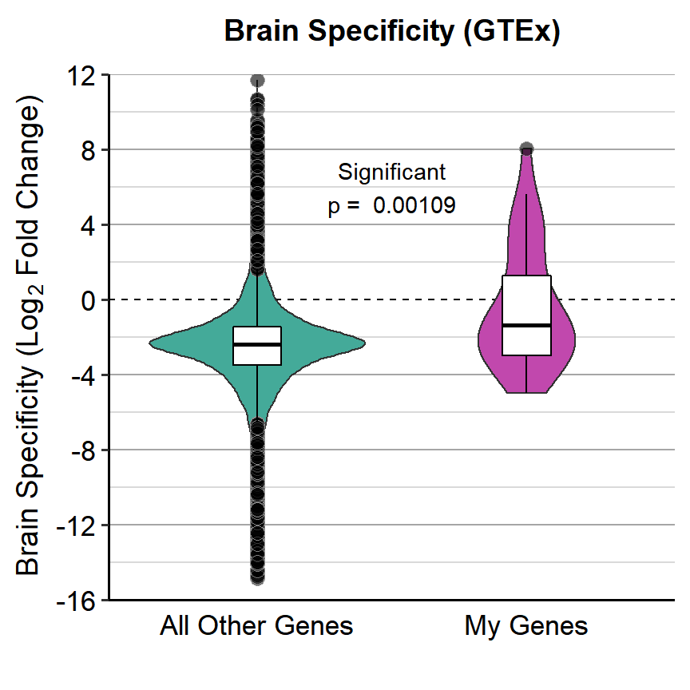

```r
bs_plot <- brain_spec %>%
  select(Human_ID, Human_Symbol, BrainSpec, Gene_Group) %>%
  unique() %>%
  filter(BrainSpec != -Inf, BrainSpec != Inf) %>%
  ggplot(aes(x = Gene_Group, y = BrainSpec, fill = Gene_Group)) +
  geom_hline(yintercept = 0, linetype = "dashed") +
  geom_hline(yintercept = c(seq(-16, -2, 2), seq(2, 12, 2)),
             linetype = "solid", color = "grey85") +
  geom_hline(yintercept = c(seq(-16, -4, 4), seq(4, 12, 4)),
             linetype = "solid", color = "grey65") +
  geom_violin(width = 0.8) +
  geom_boxplot(fill = "white", color = "black", width = 0.18,
               outlier.size = 3, outlier.shape = 21, outlier.color = "grey80",
               outlier.fill = "black", outlier.alpha = 0.6) +
  labs(x = "", y = expression("Brain Specificity (Log "[2]*" Fold Change)"),
       title = "Brain Specificity (GTEx)\n") +
  scale_y_continuous(limits = c(-16, 12), breaks = seq(-16, 12, 4),
                     expand = c(0, 0.00001)) +
  scale_x_discrete(expand = c(0, 0.55)) +
  scale_fill_manual(values = c("#44AA99", "#C148AD", "grey80")) +
  theme(legend.position = "none", axis.ticks.x = element_blank(),
        panel.grid = element_blank(),
        axis.text = element_text(size = 13),
        axis.title = element_text(size = 14),
        plot.title = element_text(face = "bold"),
        panel.border = element_blank(),
        axis.line = element_line(color = "black"))

if (bs_stats$p < 0.05){
  bs_plot <- bs_plot + annotate(geom = "text", x = 1.5, y = 6,
                                label = paste("Significant\np = ", bs_stats$p))
} else {
  bs_plot <- bs_plot + annotate(geom = "text", x = 1.5, y = 6,
                                label = paste("Not significant\np = ",
                                              bs_stats$p))
}

bs_plot
```

#### Expression of Individual Genes Across Tissues

We can also plot specific genes of interest. Below is a custom function for that.

```r
vert_gene_plot <- function(gene_name) {
  gtex_spec %>%
    mutate(System = fct_rev(case_when(
      Tissue == "BRN-CB-b" | Tissue == "BRN-CTX-b" ~ NA_character_,
      Tissue == "CELL-FB" | Tissue == "CELL-LYM" ~ NA_character_,
      TRUE ~ as.character(System)))) %>%
    filter(Human_Symbol == gene_name, !is.na(System)) %>%
    ggplot(aes(x = fct_rev(Tissue), color = System)) +
    geom_point(aes(y = Median_TPM), shape = 4, stroke = 1.5, size = 3) +
    scale_x_discrete(expand = c(0, 1.1)) +
    scale_color_manual(values = c("#9359CD", "grey60")) +
    labs(x = "Tissue", y = "Median TPM", fill = "System") +
    theme(legend.title.align = 0.5, legend.position = "none",
          legend.margin = margin(-1.25, 0, 0, 0, "cm"),
          panel.grid.major.y = element_blank(),
          panel.grid.minor.x = element_blank(),
          panel.grid.major.x = element_line(color = "grey60"),
          axis.text.y = element_text(size = 7.25),
          axis.title.x = element_text(size = 11, color = "white"),
          axis.text.x = element_text(size = 11),
          plot.margin = margin(0.25, 0.25, 0.25, 0.25, "cm"),
          strip.text = element_text(size = 11)) +
    coord_flip() +
    facet_wrap(~ Human_Symbol, ncol = 4, nrow = 1, scales = "free_y")
}
```

Apply the function on genes that seem interesting to you, like below. The example gene, *KIF5A*, has higher expression in the cortex than other regions of the brain and has higher expression in the brain than the rest of the body.

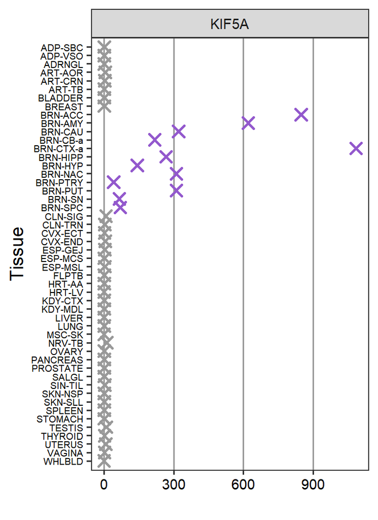

```r
vert_gene_plot("KIF5A")
```

## Save Dataframes

Finally, we will save all of the dataframes from these analyses, including:

- Sex, Tissue, Sex:Tissue ANOVA results
- Tissue effect post-hoc results
- Tissue effect CLD results
- Sex:Tissue interaction results
- Brain specificity results for each gene, including the median TPM in each tissue and the overall sum of the median expression across all brain and body tissues

```r
write.csv(bysex_tissue_anovas, anova_file)
write.csv(tukey_tissue, tissue_effect_file)
write.csv(cld_df, tissue_cld_file)
write.csv(highest_region_df, highest_cld_file)
write.csv(tukey_sex_tissue, interaction_file)
write.csv(brain_spec %>% filter(Gene_Group == "My Genes"), brain_spec_file)
```